# Prosper Loan Data EDA

Shahrooz Govahi

March 12, 2017

========================================================

Base on LoanStatus categories; I think one possible goal for this EDA should be looking at different features and predict either that loan will be Completed or Failed. By Failed loans I am referring to chargedoff or Defaulted loans. The other categories are not useful for this purpose. So I am defining a new variable LoanStatusLabel. I will put it’s value as Completed if it’s Completed and Failed if it’s Defaulted or Chargedoff and NA for other categories (e.g.Cancelled, Current).

# Univariate Plots Section

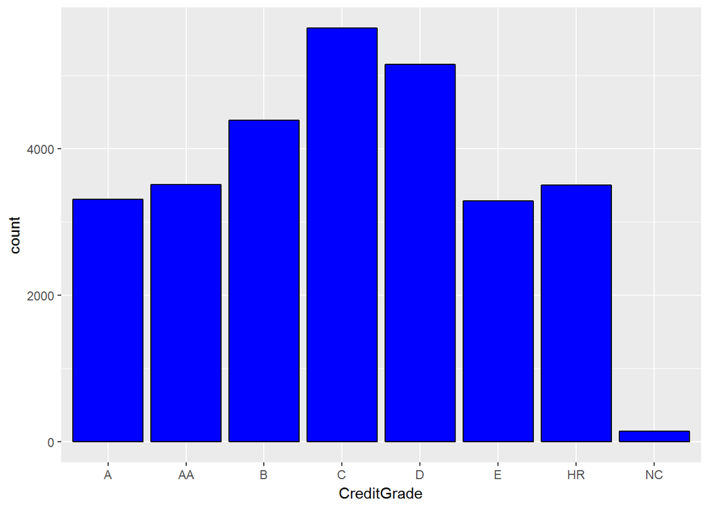

```
##     A    AA     B     C     D     E    HR    NC  NA's
##  3314  3509  4389  5648  5153  3289  3505   141 26136
```

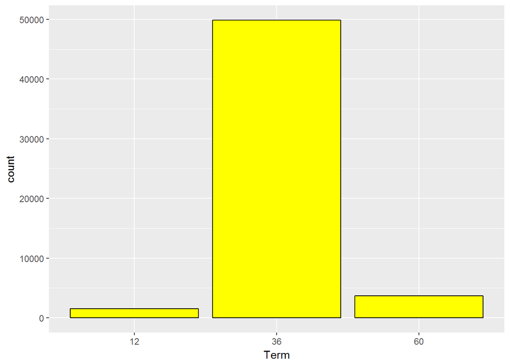

```
##    12    36    60
##  1532 49856  3696
```

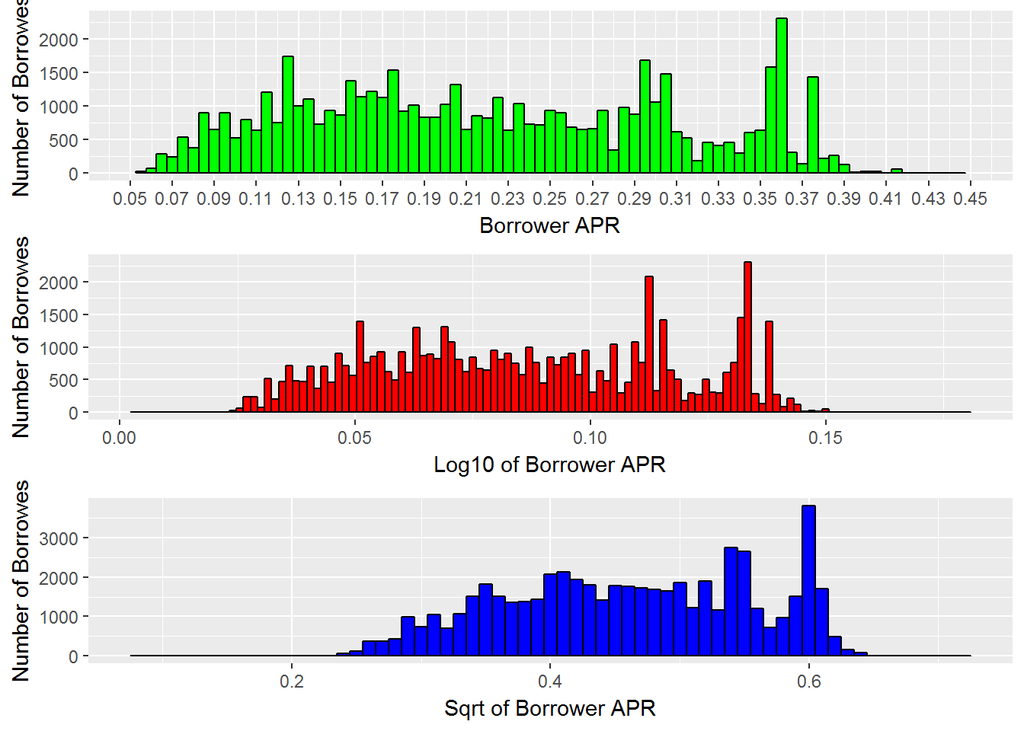

```
##    Min. 1st Qu.  Median    Mean 3rd Qu.    Max.    NA's
## 0.00653 0.14970 0.21430 0.22220 0.29510 0.51230      25
```

The most frequent Borrower APR is 0.36; By transforming data with Square root, the distribution result is more smoother.

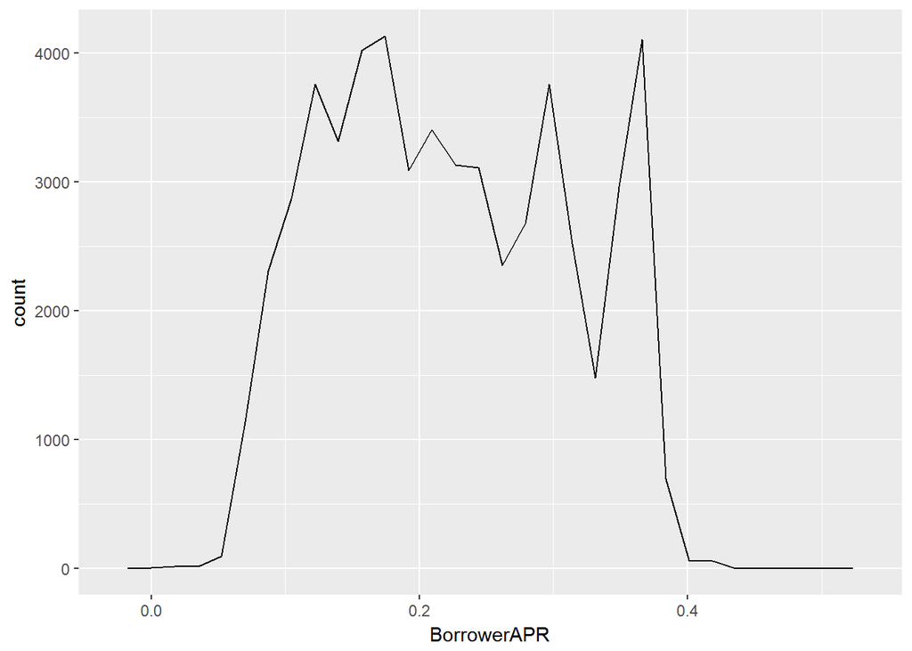

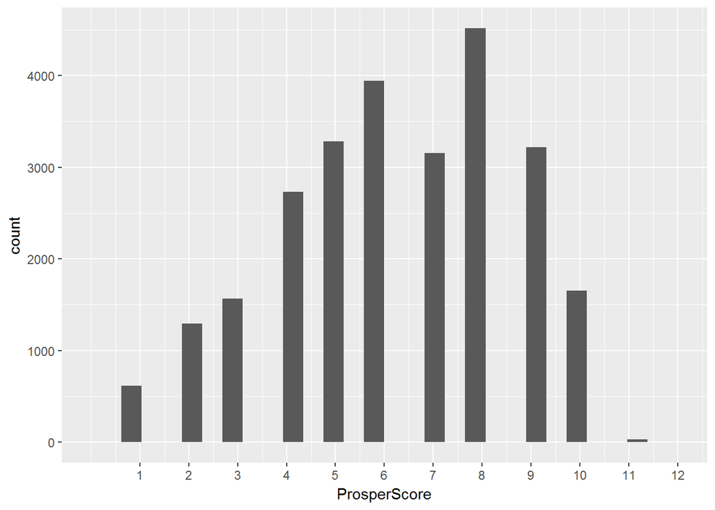

```
##    Min. 1st Qu.  Median    Mean 3rd Qu.    Max.    NA's
##   1.000   5.000   6.000   6.266   8.000  11.000   29079
```

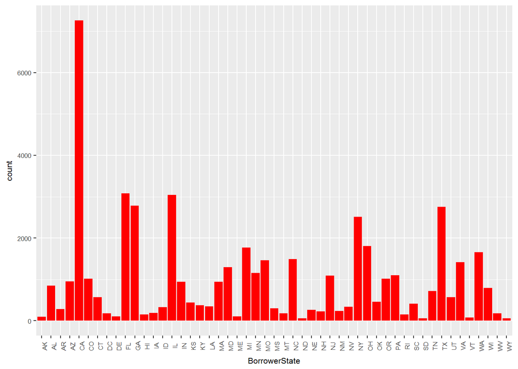

```
##   AK   AL   AR   AZ   CA   CO   CT   DC   DE   FL   GA   HI   IA   ID   IL
##   93  848  279  946 7263 1013  569  174  103 3077 2783  153  186  328 3039
##   IN   KS   KY   LA   MA   MD   ME   MI   MN   MO   MS   MT   NC   ND   NE
##  944  441  370  348  944 1289  101 1767 1151 1459  295  181 1487   52  262
##   NH   NJ   NM   NV   NY   OH   OK   OR   PA   RI   SC   SD   TN   TX   UT
##  228 1090  230  339 2515 1808  460 1018 1098  153  414   61  716 2752  569
##   VA   VT   WA   WI   WV   WY NA's
## 1417   76 1655  793  178   57 5512
```

California has the most users of Prosper loan services.

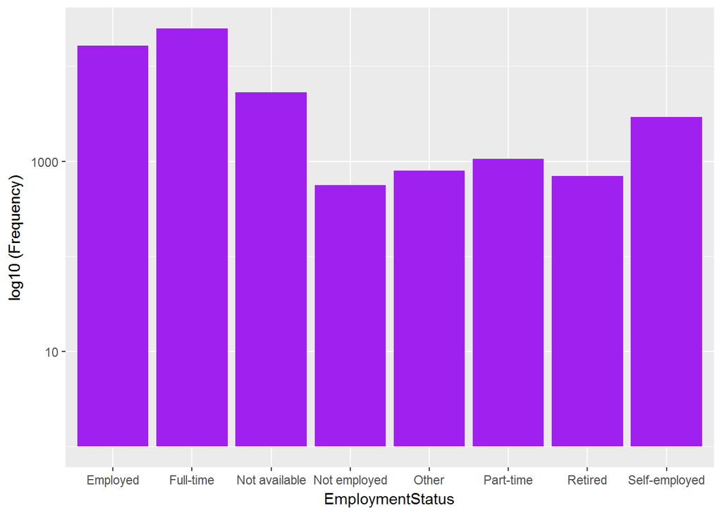

```
##      Employed     Full-time Not available  Not employed         Other
##         16491         24957          5346           561           798
##     Part-time       Retired Self-employed          NA's
##          1056           697          2926          2252
```

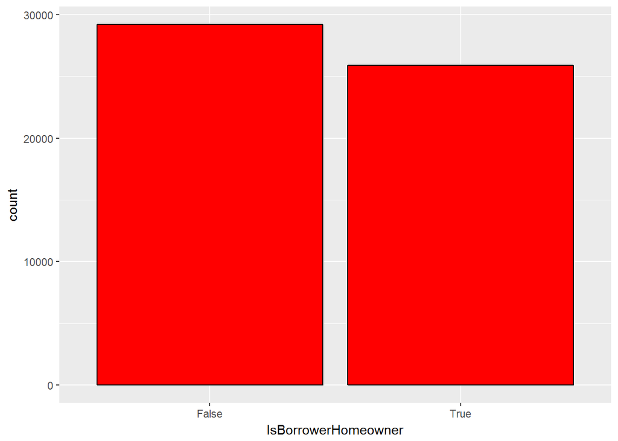

```
## False  True
## 29199 25885
```

Home owners and not home owners numbers are very close to each other;

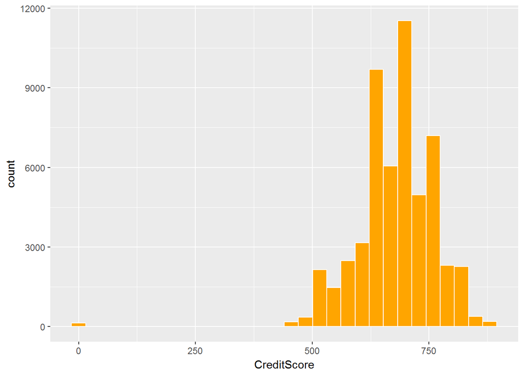

```
##    Min. 1st Qu.  Median    Mean 3rd Qu.    Max.    NA's
##    10.0   650.0   690.0   681.7   730.0   890.0     590
```

The CreditScore = 10 should be an error in our data; So I will focus on scores more than 460;

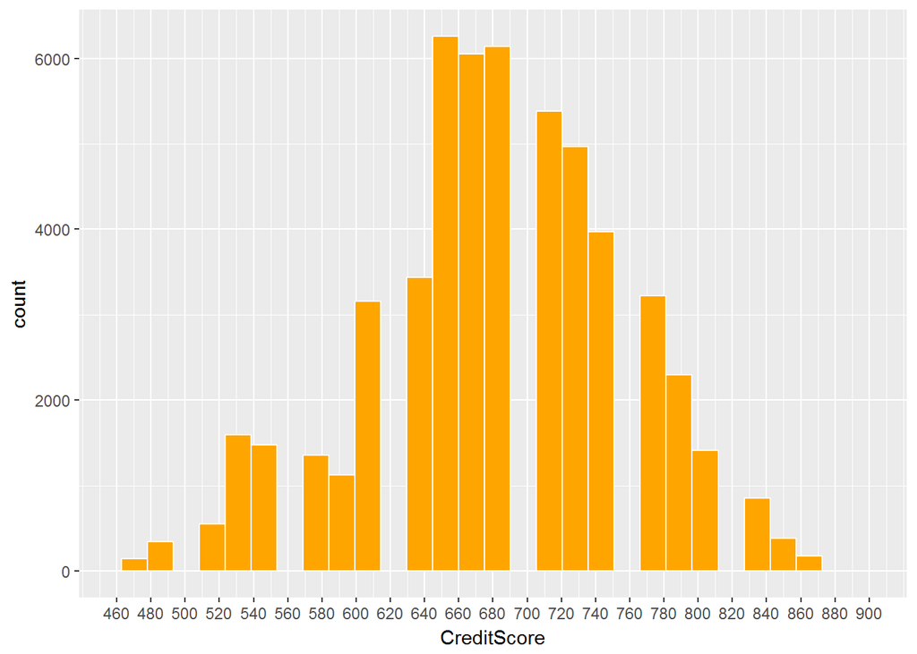

There are some gaps between scores. e.g. There is no person with credit score equal to 700 or 560. It seems like credit scores has 7 clusters.

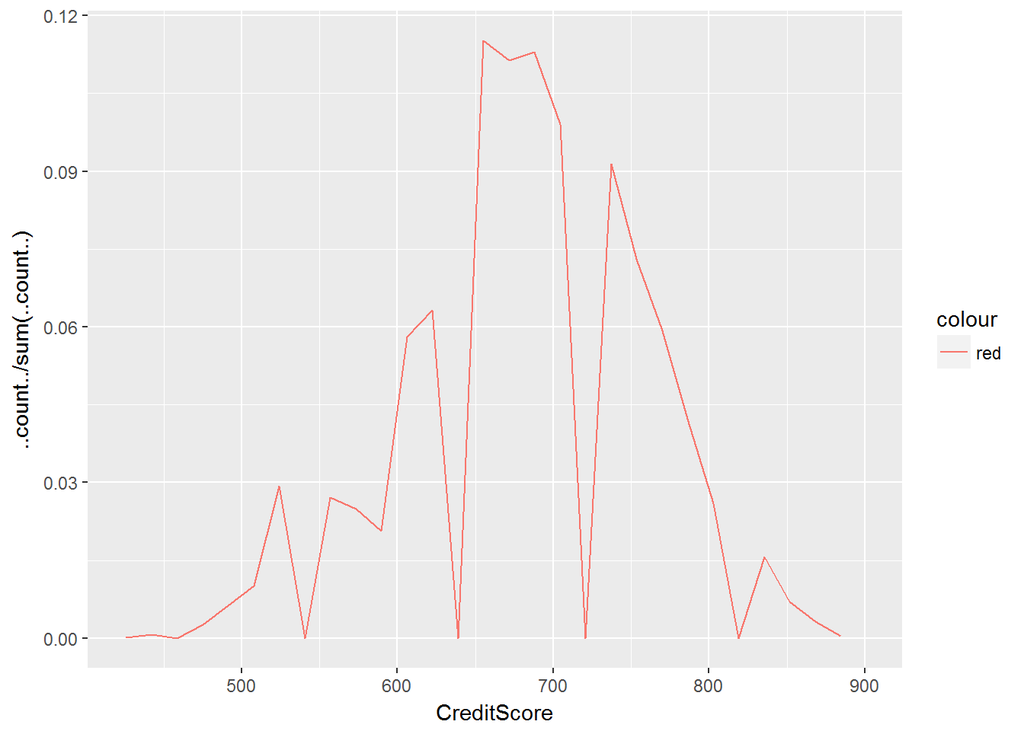

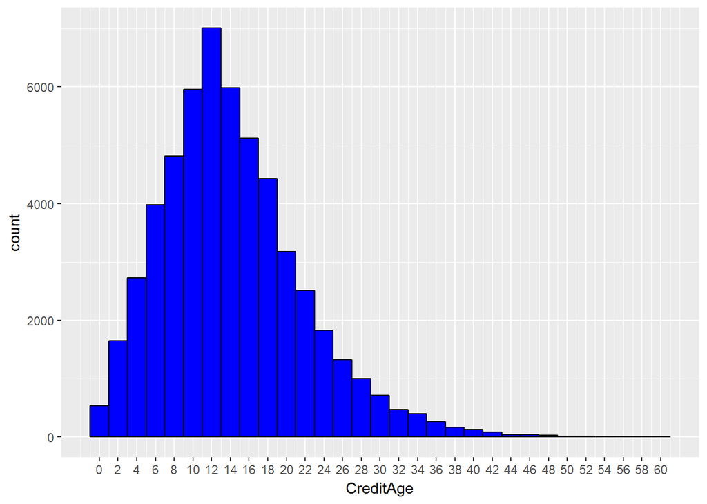

The CreditAge is a little right skewed. So I will look at Square root of the data as well.

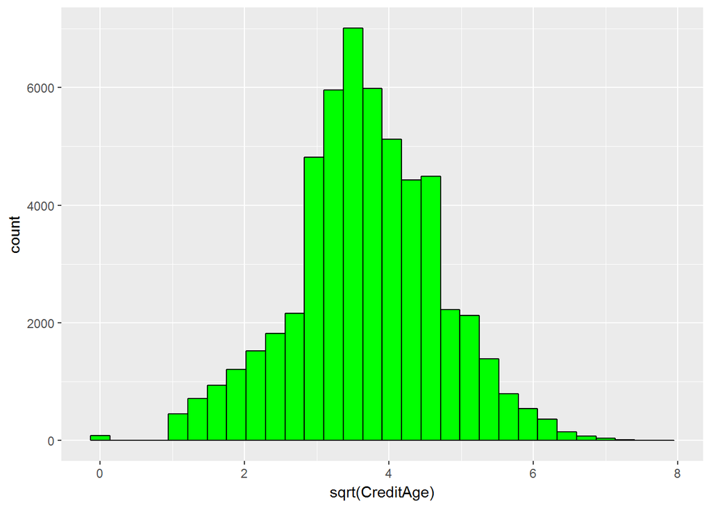

```
##    Min. 1st Qu.  Median    Mean 3rd Qu.    Max.    NA's
##    0.00    9.00   14.00   14.68   19.00   61.00     696
```

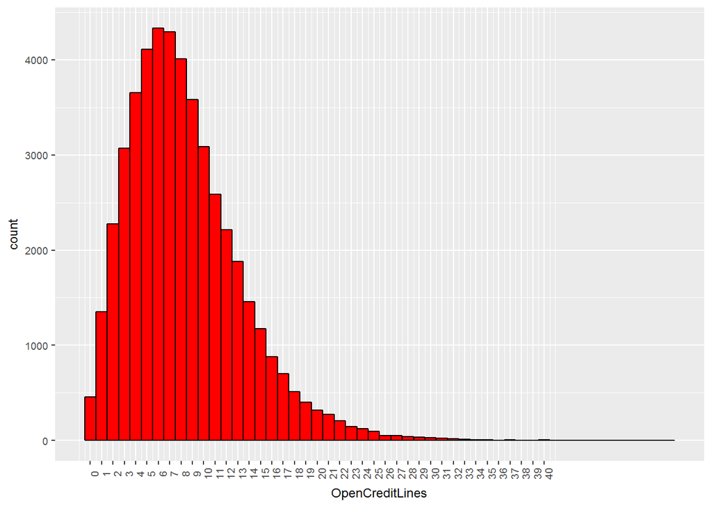

The OpenCreditLines is a little skewed. I tried transforming it with log10 bot the result is not very useful.

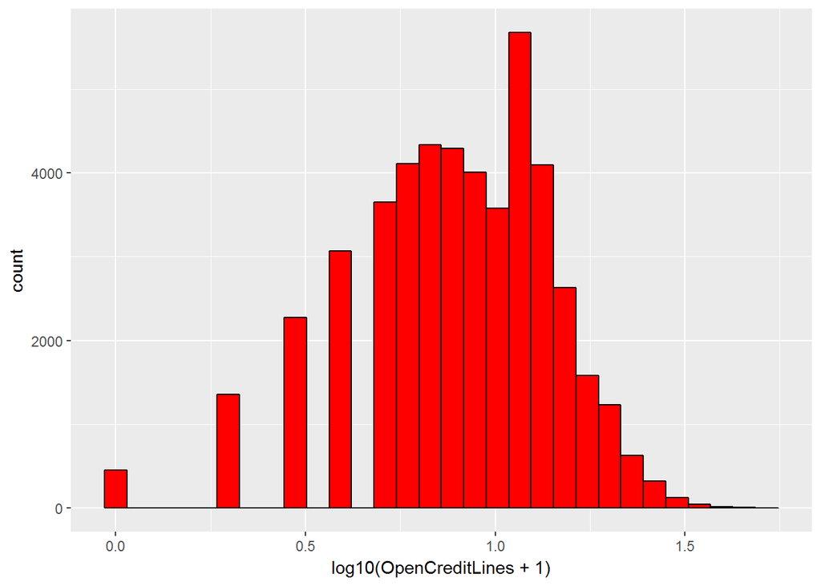

```
##    Min. 1st Qu.  Median    Mean 3rd Qu.    Max.    NA's
##   0.000   5.000   8.000   8.338  11.000  51.000    7600
```

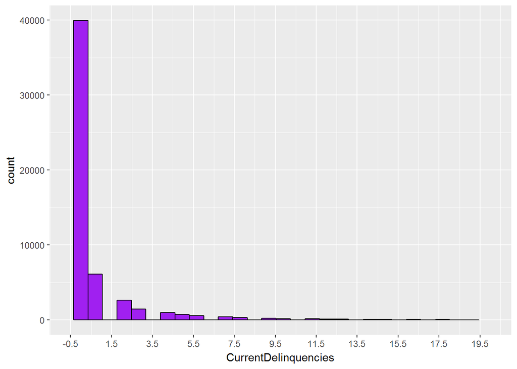

```
##    Min. 1st Qu.  Median    Mean 3rd Qu.    Max.    NA's
##  0.0000  0.0000  0.0000  0.9062  1.0000 83.0000     696
```

Most of the users has no Current Delinquency.

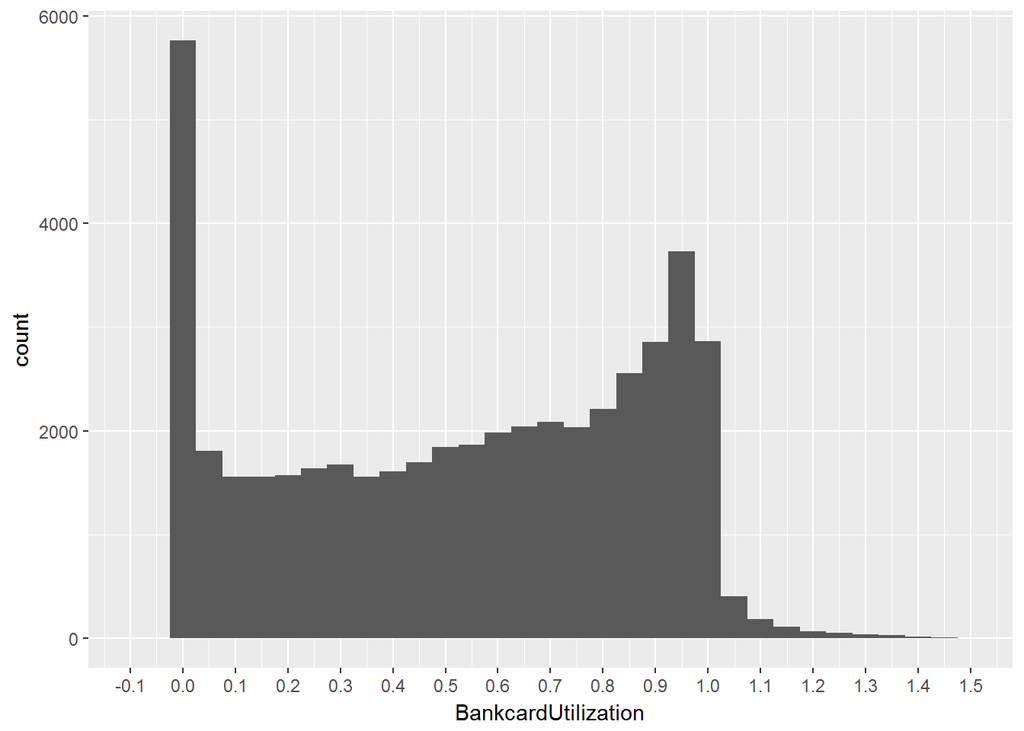

```
##    Min. 1st Qu.  Median    Mean 3rd Qu.    Max.    NA's
##    0.00    0.21    0.56    0.53    0.85    5.95    7600
```

BankcardUtilization has a bimodal distribution. Most users utilize 0 percent of their credit cards and next the majority of users utilize 95% of their bank cards.

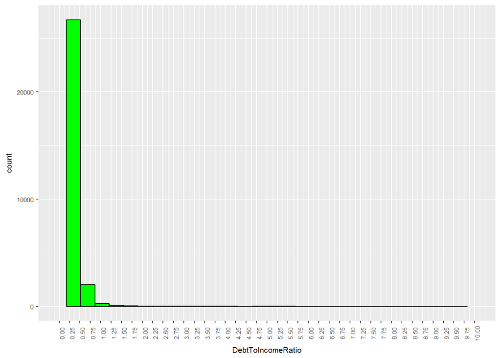

```
## [1] 289
```

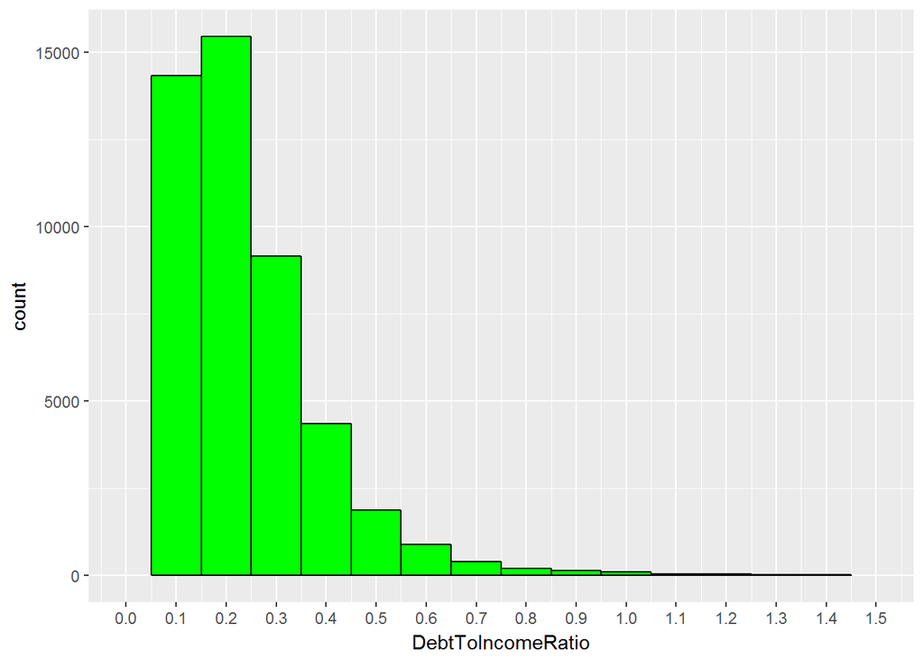

```
##    Min. 1st Qu.  Median    Mean 3rd Qu.    Max.    NA's
##    0.00    0.13    0.20    0.29    0.30   10.01    4230
```

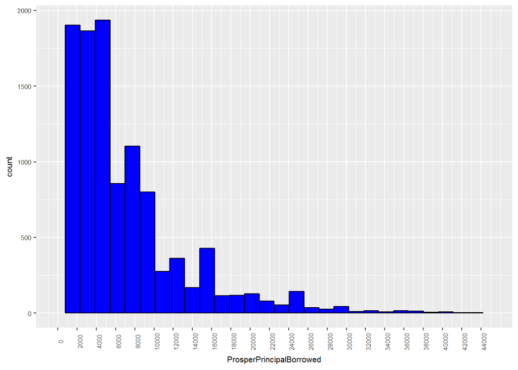

Most of the loans are under $6000. The distribution is right skewed;

```r
loan_under_6000 <- subset(loan, ProsperPrincipalBorrowed <= 6000)
nrow(loan_under_6000)
```

```
## [1] 6235
```

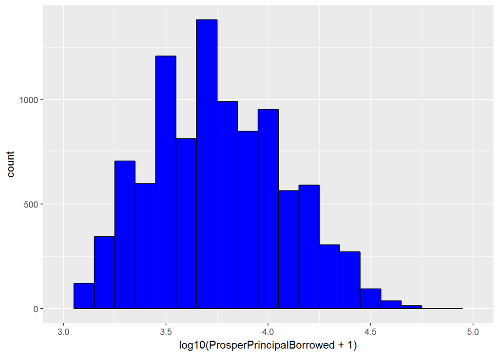

```
##    Min. 1st Qu.  Median    Mean 3rd Qu.    Max.    NA's
##       0    3000    5000    7105    9500   60000   44545
```

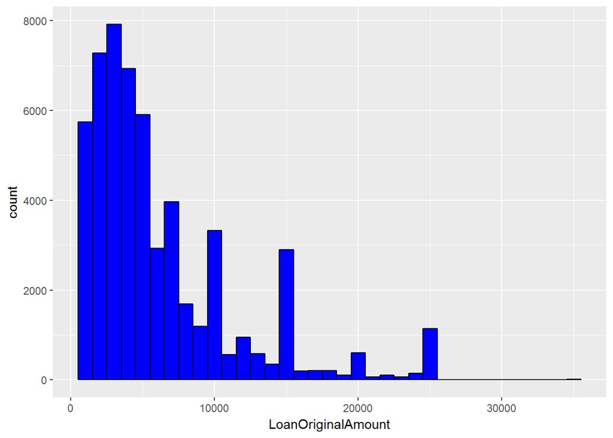

There are some ouliers in LoanOriginalAmount, so I changed the scales.

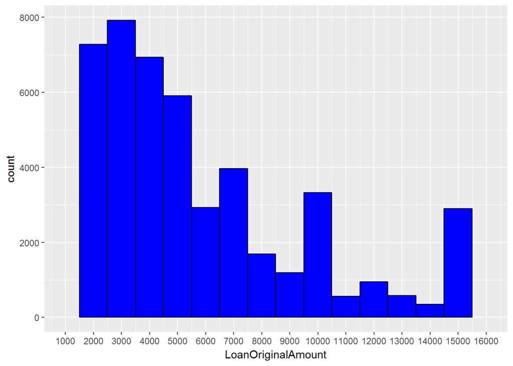

```
##    Min. 1st Qu.  Median    Mean 3rd Qu.    Max.
##    1000    2600    4500    6262    8000   35000
```

The most popular LoanOriginalAmounts are between $2500 and $3500.

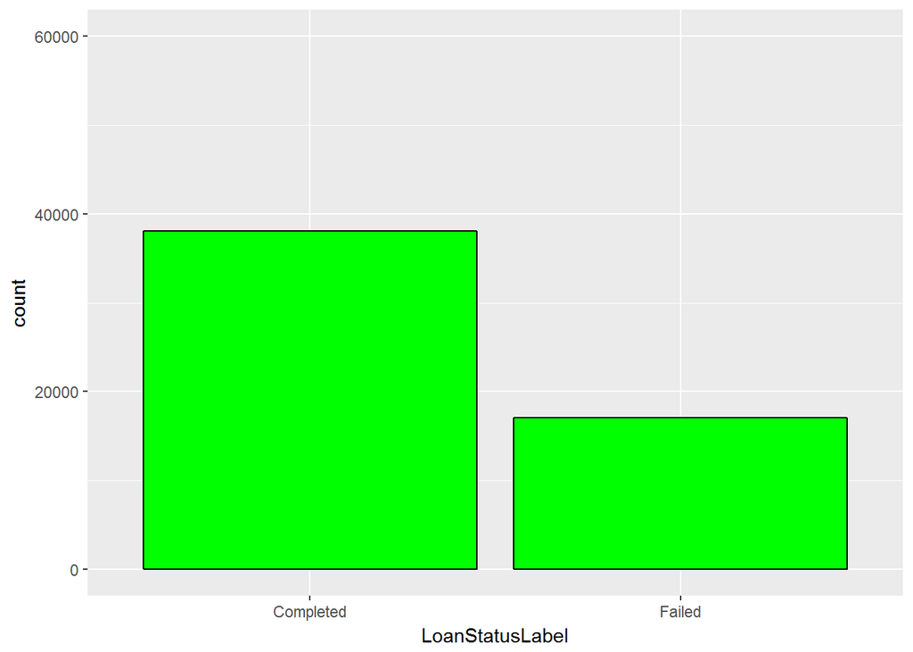

```
##
## Completed    Failed
##     38074     17010
```

# Univariate Analysis

### What is the structure of your dataset?

The original data set contains 113,937 observations with 81 variables. I choose some of those variablels and focusing only on Completed or failed loans for doing EDA; It means that I am working on 55084 observations with 16 variables.

```
## [1] 55084    16
```

```
## 'data.frame':    55084 obs. of  16 variables:
##  $ CreditGrade             : Factor w/ 8 levels "A","AA","B","C",..: 4 7 4 NA 2 5 NA NA NA NA ...
##  $ Term                    : Factor w/ 3 levels "12","36","60": 2 2 2 2 2 2 2 3 2 2 ...
##  $ BorrowerAPR             : num  0.165 0.283 0.15 0.358 0.132 ...
##  $ ProsperScore            : num  NA NA NA 5 NA NA 5 3 9 9 ...
##  $ BorrowerState           : Factor w/ 51 levels "AK","AL","AR",..: 6 11 NA 10 NA 23 15 35 6 5 ...
##  $ EmploymentStatus        : Factor w/ 8 levels "Employed","Full-time",..: 8 3 2 5 3 2 1 1 2 1 ...
##  $ IsBorrowerHomeowner     : Factor w/ 2 levels "False","True": 2 1 1 2 2 1 1 1 2 1 ...
##  $ CreditScore             : num  650 490 650 710 770 630 690 670 710 750 ...
##  $ CreditAge               : num  6 5 7 13 16 4 15 38 10 24 ...
##  $ OpenCreditLines         : int  4 NA 2 9 NA 4 7 6 16 4 ...
##  $ CurrentDelinquencies    : int  2 1 3 0 2 1 0 0 0 1 ...
##  $ BankcardUtilization     : num  0 NA 0.32 0.97 NA 0.08 0.84 0.3 0.09 0.13 ...
##  $ DebtToIncomeRatio       : num  0.17 0.06 0.27 0.49 0.12 0.09 0.39 0.11 0.26 0.11 ...
##  $ ProsperPrincipalBorrowed: num  NA NA NA NA NA NA NA NA NA NA ...
##  $ LoanOriginalAmount      : int  9425 3001 1000 4000 10000 3000 2000 4000 4000 10000 ...
##  $ LoanStatusLabel         : Factor w/ 2 levels "Completed","Failed": 1 1 1 2 2 1 2 1 1 1 ...
```

```
##   CreditGrade    Term        BorrowerAPR       ProsperScore
##  C      : 5648   12: 1532   Min.   :0.00653   Min.   : 1.000
##  D      : 5153   36:49856   1st Qu.:0.14974   1st Qu.: 5.000
##  B      : 4389   60: 3696   Median :0.21434   Median : 6.000
##  AA     : 3509              Mean   :0.22219   Mean   : 6.266
##  HR     : 3505              3rd Qu.:0.29510   3rd Qu.: 8.000
##  (Other): 6744              Max.   :0.51229   Max.   :11.000
##  NA's   :26136              NA's   :25        NA's   :29079
##  BorrowerState        EmploymentStatus IsBorrowerHomeowner  CreditScore
##  CA     : 7263   Full-time    :24957   False:29199         Min.   : 10.0
##  FL     : 3077   Employed     :16491   True :25885         1st Qu.:650.0
##  IL     : 3039   Not available: 5346                       Median :690.0
##  GA     : 2783   Self-employed: 2926                       Mean   :681.7
##  TX     : 2752   Part-time    : 1056                       3rd Qu.:730.0
##  (Other):30658   (Other)      : 2056                       Max.   :890.0
##  NA's   : 5512   NA's         : 2252                       NA's   :590
##    CreditAge     OpenCreditLines  CurrentDelinquencies BankcardUtilization
##  Min.   : 0.00   Min.   : 0.000   Min.   : 0.0000      Min.   :0.00
##  1st Qu.: 9.00   1st Qu.: 5.000   1st Qu.: 0.0000      1st Qu.:0.21
##  Median :14.00   Median : 8.000   Median : 0.0000      Median :0.56
##  Mean   :14.68   Mean   : 8.338   Mean   : 0.9062      Mean   :0.53
##  3rd Qu.:19.00   3rd Qu.:11.000   3rd Qu.: 1.0000      3rd Qu.:0.85
##  Max.   :61.00   Max.   :51.000   Max.   :83.0000      Max.   :5.95
##  NA's   :696     NA's   :7600     NA's   :696          NA's   :7600
##  DebtToIncomeRatio ProsperPrincipalBorrowed LoanOriginalAmount
##  Min.   : 0.00     Min.   :    0            Min.   : 1000
##  1st Qu.: 0.13     1st Qu.: 3000            1st Qu.: 2600
##  Median : 0.20     Median : 5000            Median : 4500
##  Mean   : 0.29     Mean   : 7105            Mean   : 6262
##  3rd Qu.: 0.30     3rd Qu.: 9500            3rd Qu.: 8000
##  Max.   :10.01     Max.   :60001            Max.   :35000
##  NA's   :4230      NA's   :44545
##   LoanStatusLabel
##  Completed:38074
##  Failed   :17010
##
##
##
##
##
```

### What is the main feature of interest in your dataset?

In this investigation I want to consider final result of a loan: LoanStatusLabel as the main feature of interest and I am looking at other features as predictors of this target.

### What other features in the dataset do you think will help support your

### investigation into your feature(s) of interest?

I choose these 15 features to help my investigation: CreditGrade, Term, ProsperScore, BorrowerAPR, BorrowerState, EmploymentStatus, IsBorrowerHomeowner, CreditScore, CreditAge, OpenCreditLine, CurrentDelinquencies, BankcardUtilization, DebtToIncomeRatio, ProsperPrincipalBorrowed, LoanOriginalAmount.

### Did you create any new variables from existing variables in the dataset?

I created these variables: 1. CreditAge, base on FirstRecordedCreditLine and DateCreditPulled 2. CreditScore, base on CreditScoreRangeLower and CreditScoreRangeUpper I calculated the average of these two ranges to use one variable. 3. LoanStatusLabel, base on LoanStatus I create 2 categories: Completed, Failed.

### Of the features you investigated, were there any unusual distributions?

The EmploymentStatus is right skewed. The reason should be that, the prosper company only focus on Employed or Full_time or Self-employed applicants. Therefore the majority of it’s clients are in these three categories and very few of them are in retired or other kinds of employment types. BankcardUtilization has a bimodal distribution. One peak occurs at 0 utilization and the other is at 95% utilization.

### Did you perform any operations on the data to tidy, adjust, or change the

### form of the data? If so, why did you do this?

*I only look at two kinds of LoanStaus, because I am trying to find out what’s the most effective features for predicting a Completed loan. So I cleaned all other LoanStatuses.* I changed the Term variable as factor. Because it has only 3 fixed values: 12, 36, 60. *For all graphs, I put NA’s aside for looking at values only.* Another issue was distribution type for some of the features, like BorrowerAPR. It does not have a normal distribution. So I tried log10 and sqrt of this variable, and I think sqrt of values is smoother and more similar to normal distribution.

# Bivariate Plots Section

### Correlations

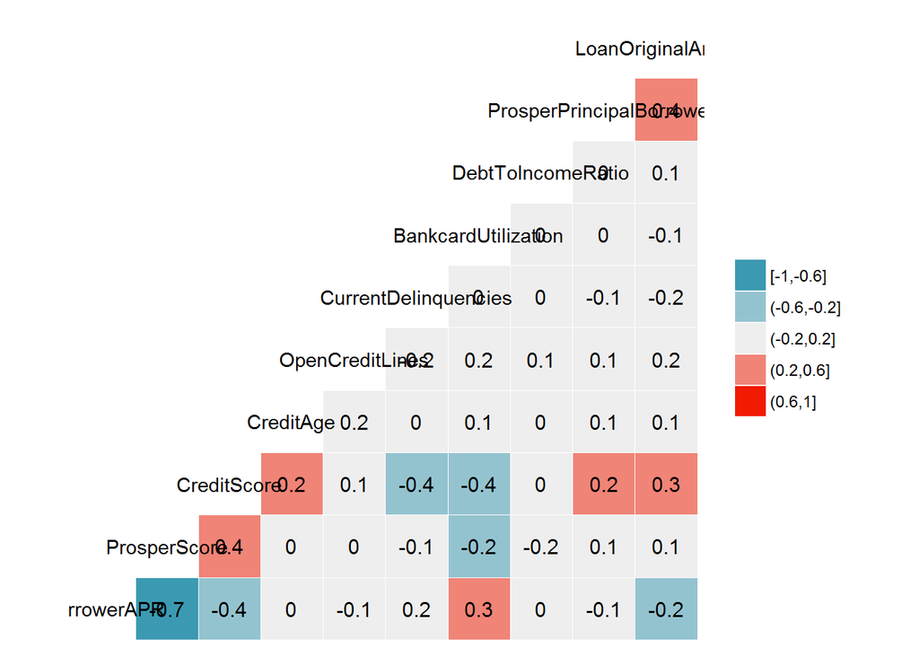

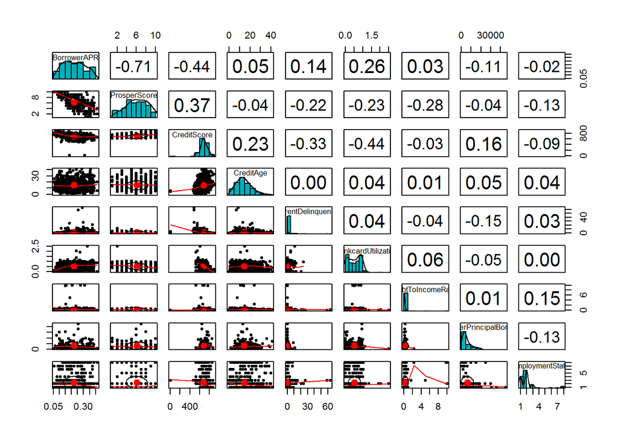

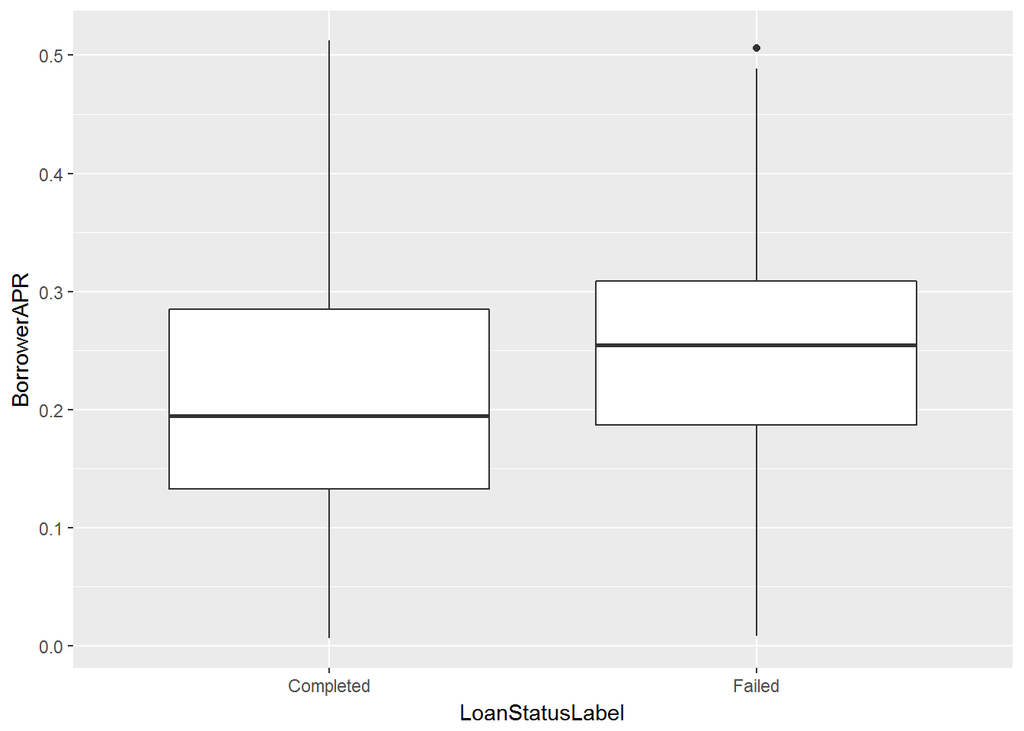

```
## loan$LoanStatusLabel: Completed
##    Min. 1st Qu.  Median    Mean 3rd Qu.    Max.    NA's
## 0.00653 0.13270 0.19480 0.20880 0.28500 0.51230      25
## --------------------------------------------------------
## loan$LoanStatusLabel: Failed
##    Min. 1st Qu.  Median    Mean 3rd Qu.    Max.
## 0.00864 0.18690 0.25440 0.25220 0.30910 0.50630
```

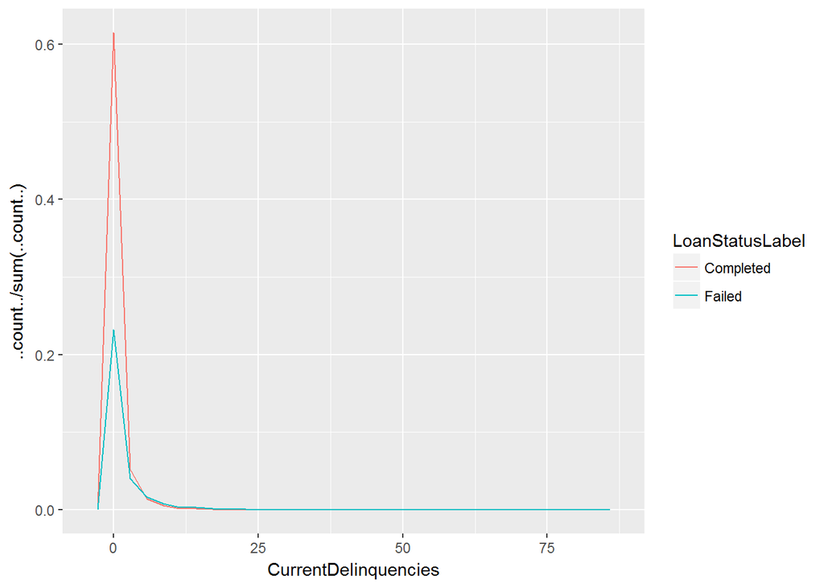

Around 60% of completed loans has zero CurrentDelinquencies and this number is 20% for failed loans.

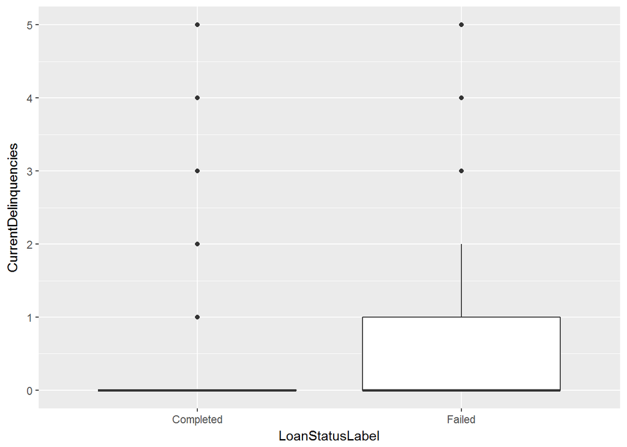